# midterm project team 5

2022-10-16

install some packages or libraries

```r
library(ggplot2)
library(ezids)
library(dplyr)
```

## read data

Read the data .CSV files of adults arrest in DC area from 2016-2021

```r
df_2016<-data.frame(read.csv("Arrests 2016 Public.csv"))[,1:14]
df_2017<-data.frame(read.csv("Arrests 2017 Public.csv"))[,1:14]
df_2018<-data.frame(read.csv("Arrests by Year, 2018.csv"))[,1:14]
df_2019<-data.frame(read.csv("Arrests by Year, 2019.csv"))[,1:14]
df_2020<-data.frame(read.csv("Arrests by Year 2020.csv"))[,1:14]
df_2021<-data.frame(read.csv("2021 Adult Arrests.csv"))[,1:14]
```

Note that the colnames of df_2016 and df_2017 are not the same with others. But those indices are just about arrest location which is not what we are investigating. Therefore I just combined them by the same indices that we need. (A-N columns) ##Merge Multiple CSV Files bind by rows

```r
DF<-rbind(df_2016,df_2017,df_2018,df_2019,df_2020,df_2021)
colnames(DF)
```

```
##  [1] "Arrestee.Type"       "Arrest.Year"         "Arrest.Date"
##  [4] "Arrest.Hour"         "CCN"                 "Arrest.Number."
##  [7] "Age"                 "Defendant.PSA"       "Defendant.District"
## [10] "Defendant.Race"      "Defendant.Ethnicity" "Defendant.Sex"
## [13] "Arrest.Category"     "Charge.Description"
```

```r
xkablesummary(DF)
```

Table: Statistics summary.

|  | Arrestee.Type | Arrest.Year | Arrest.Date | Arrest.Hour | CCN | Arrest.Number. | Age | Defendant.PSA | Defendant.District | Defendant.Race | Defendant.Ethnicity | Defendant.Sex | Arrest.Category | Charge.Description |
| --- | --- | --- | --- | --- | --- | --- | --- | --- | --- | --- | --- | --- | --- | --- |
| Min | Length:152386 | Min. :2016 | Length:152386 | Min. : 0.0 | Length:152386 | Length:152386 | Min. : 18.0 | Length:152386 | Length:152386 | Length:152386 | Length:152386 | Length:152386 | Length:152386 | Length:152386 |
| Q1 | Class :character | 1st Qu.:2017 | Class :character | 1st Qu.: 6.0 | Class :character | Class :character | 1st Qu.: 25.0 | Class :character | Class :character | Class :character | Class :character | Class :character | Class :character | Class :character |
| Median | Mode :character | Median :2018 | Mode :character | Median :12.0 | Mode :character | Mode :character | Median : 32.0 | Mode :character | Mode :character | Mode :character | Mode :character | Mode :character | Mode :character | Mode :character |
| Mean | NA | Mean :2018 | NA | Mean :11.8 | NA | NA | Mean : 35.2 | NA | NA | NA | NA | NA | NA | NA |
| Q3 | NA | 3rd Qu.:2019 | NA | 3rd Qu.:18.0 | NA | NA | 3rd Qu.: 43.0 | NA | NA | NA | NA | NA | NA | NA |
| Max | NA | Max. :2021 | NA | Max. :23.0 | NA | NA | Max. :121.0 | NA | NA | NA | NA | NA | NA | NA |

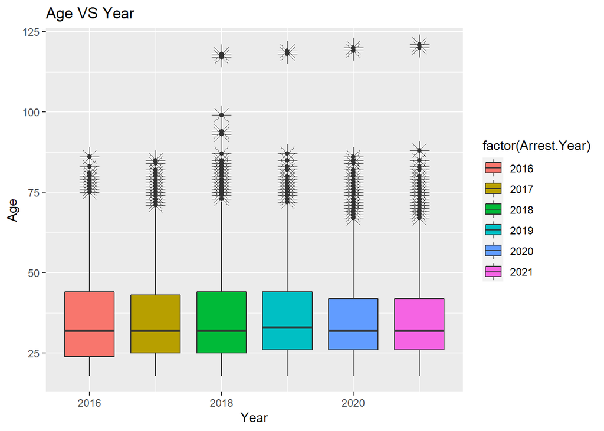

```r
PADM = ggplot(DF, aes(group = factor(Arrest.Year), y = Age,x= Arrest.Year, fill = factor(Arrest.Year))) +
  geom_boxplot() +
  geom_boxplot(outlier.shape=8, outlier.size=5) +
  labs(title="Age VS Year", x="Year", y = "Age")
PADM
```

This plot is to compare the age of people who get arrested with each different year. From the plot, we can see that there are lots of outliers. We need to get rid of the outliers first.

```r
Q1 = quantile(DF$Age, .25)
Q3 = quantile(DF$Age, .75)
IQR = IQR(DF$Age)

#only keep rows in dataframe that have values within 1.5*IQR of Q1 and Q3
ndf = subset(DF, DF$Age> (Q1 - 1.5*IQR) & DF$Age< (Q3 + 1.5*IQR))

#view row and column count of new data frame
dim(ndf)
```

```
## [1] 151552     14
```

```r
dim(DF)
```

```
## [1] 152386     14
```

Removed 834 outliers.

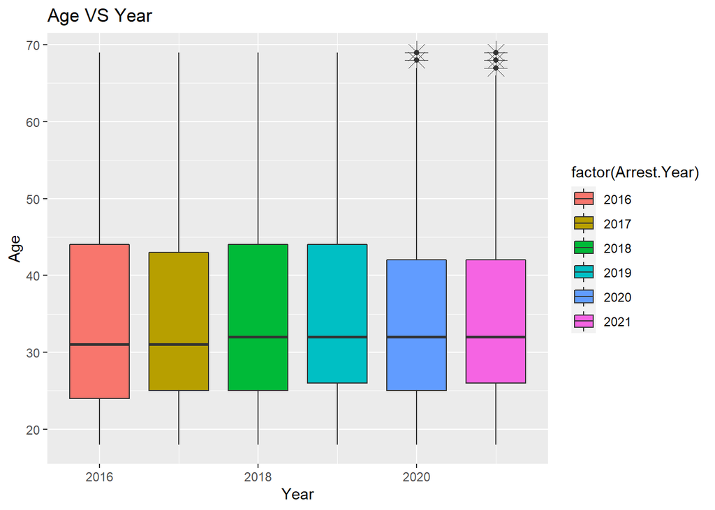

```r
ATY = ggplot(ndf, aes(group = factor(Arrest.Year), y = Age, x= Arrest.Year, fill = factor(Arrest.Year))) +
  geom_boxplot() +
  geom_boxplot(outlier.shape=8, outlier.size=5) +
  labs(title="Age VS Year", x="Year", y = "Age")
ATY
```